# RM 8.5 7DADM — Random Forest on a Change-from-Today Target

Maddee Wiggins (FlowWest)

2026-09-16

# Objective

This document reframes the target as the **change from today** rather than the absolute level: the forest is trained on `rm_8_5_7dadm - dadm_m0` and the prediction adds `dadm_m0` back. Because `dadm_m0` is a real RM 8.5 observation — identical at training and serving time — the model is anchored on something the mismatch cannot corrupt, and only has to learn the correction.

The prediction of the change from today is better suited for anamolous years because the random forest model has a difficult time predicting outside of its training dataset values. However, the delta between day 0 and day 7 is not anamolous even in anamolous years.

Two supporting additions, each independently significant (p < 0.001):

- **RM 8.5’s own trend** (`dadm_trend`, `tmax_trend`) — the model previously had trend features for Camp Polk but none for RM 8.5 itself.
- **Trajectory summaries** (`traj_air_max_max`, `traj_air_max_mean`, `traj_air_min_mean`, `traj_warming`) — at lead 7 the forecast spans 28 individual columns and `mtry` samples only a third of them, so explicit summaries concentrate a signal the forest otherwise has to rediscover.

Overall structure: dynamical.org GFS weather source, 500-tree forests, chronological 80/20 split, same-day RM 8.5 inputs.

```r
month_start     <- 5
month_end       <- 10
lead_days_vec   <- c(1:7)
ntree           <- 500
test_frac       <- 0.20
trend_window    <- 5
threshold_7dadm <- 20.0

# Most recent RM 8.5 logger export. Kept as a config value because the
# hindcast window is bounded by it — point this at the newest export and
# keep it in step with summer_2026_8_5_performance.Rmd.
rm85_logger_file <- "WC85 Rimrock bottom 2026-08-13 09_52_44 PDT.xlsx"

lead_colors <- setNames(colorRampPalette(c("#185FA5", "#4E9F50", "#C93312"))(length(lead_days_vec)),
                        as.character(lead_days_vec))
```

# Data & feature construction

```r
rm85_7dadm <- rm_8_5_historical |>
  mutate(date = as.Date(date)) |>
  filter(statistic == "7DADM") |>
  select(date, rm_8_5_7dadm = temperature)

rm85_tmax <- rm_8_5_historical |>
  mutate(date = as.Date(date)) |>
  filter(statistic == "max") |>
  select(date, rm_8_5_tmax = temperature)

cp_7dadm <- camp_polk_temperature_historical |>
  mutate(date = as.Date(date)) |>
  filter(statistic == "7DADM") |>
  select(date, cp_7dadm = temperature)

cp_tmax <- camp_polk_temperature_historical |>
  mutate(date = as.Date(date)) |>
  filter(statistic == "max") |>
  select(date, cp_tmax = temperature)

cp_flow <- camp_polk_flow_historical |>
  mutate(date = as.Date(date)) |>
  filter(statistic == "mean") |>
  select(date, cp_flow_mean = flow_cfs)

# Packaged snapshot of data-raw/dynamical_gfs_air_temp_historical.csv. Extend
# the CSV with data-raw/pull_dynamical_forecasts.py, then re-knit the
# dynamical.org chunk in data-raw/pull-historical-data.Rmd to refresh this.
dyn_raw <- dynamical_gfs_forecasts

cat(sprintf("dynamical.org archive: %s to %s, %d rows\n",
            min(dyn_raw$valid_date), max(dyn_raw$valid_date), nrow(dyn_raw)))
```

```
## dynamical.org archive: 2021-05-02 to 2026-09-07, 40929 rows
```

```r
get_forecast_dyn <- function(lead_k) {
  dyn_raw |>
    filter(lead_days == lead_k) |>
    select(valid_date, variable, value) |>
    pivot_wider(names_from = variable, values_from = value) |>
    rename(date = valid_date, air_max = temperature_2m_max,
           air_min = temperature_2m_min, cloud_pct = cloud_cover_mean)
}

get_forecast_trajectory_dyn <- function(lead_k) {
  day_tables <- map(seq_len(lead_k), function(k) {
    get_forecast_dyn(k) |>
      mutate(run_date = date - k) |>
      transmute(
        run_date,
        !!paste0("air_max_d", k) := air_max,
        !!paste0("air_min_d", k) := air_min,
        !!paste0("cloud_d",   k) := cloud_pct,
        !!paste0("julian_d",  k) := yday(date)
      )
  })
  reduce(day_tables, full_join, by = "run_date") |> arrange(run_date)
}

# Collapses the d1..dk trajectory into a handful of explicit summaries. At
# lead 7 the raw trajectory is 28 columns and mtry samples ~9 of them, so a
# tree often misses the days that actually matter; these give it the shape
# of the week directly. `traj_warming` (last day minus first) is the
# ramping-up signal that a persistence-anchored model needs in order to
# break away from today's value during a developing hot spell.
add_trajectory_summaries <- function(df, lead_k) {
  air_max_cols <- as.matrix(df[, paste0("air_max_d", 1:lead_k), drop = FALSE])
  air_min_cols <- as.matrix(df[, paste0("air_min_d", 1:lead_k), drop = FALSE])
  df$traj_air_max_max  <- apply(air_max_cols, 1, max)
  df$traj_air_max_mean <- apply(air_max_cols, 1, mean)
  df$traj_air_min_mean <- apply(air_min_cols, 1, mean)
  df$traj_warming      <- air_max_cols[, lead_k] - air_max_cols[, 1]
  df
}

build_df_dyn <- function(lead_k) {
  fcst_traj <- get_forecast_trajectory_dyn(lead_k) |>
    mutate(date = run_date + lead_k) |>
    select(-run_date)

  joined <- rm85_7dadm |>
    left_join(cp_flow  |> mutate(date = date + lead_k), by = "date") |>
    left_join(cp_7dadm |> mutate(date = date + lead_k), by = "date") |>
    left_join(cp_tmax  |> mutate(date = date + lead_k), by = "date") |>
    left_join(fcst_traj, by = "date") |>
    left_join(cp_flow  |> mutate(date = date + lead_k + 1)            |> rename(cp_flow_m1  = cp_flow_mean), by = "date") |>
    left_join(cp_flow  |> mutate(date = date + lead_k + trend_window) |> rename(cp_flow_mw  = cp_flow_mean), by = "date") |>
    left_join(cp_7dadm |> mutate(date = date + lead_k + 1)            |> rename(cp_7dadm_m1 = cp_7dadm),     by = "date") |>
    left_join(cp_7dadm |> mutate(date = date + lead_k + trend_window) |> rename(cp_7dadm_mw = cp_7dadm),     by = "date") |>
    # RM 8.5's own same-day values — no lag. The operational script runs at
    # 7pm PST and RM 8.5's daily max lands by 5-6pm on essentially every day
    # in the real 2026 record (0% after 7pm, 4.1% after 6pm), so today's
    # reading is complete at run time, like Camp Polk's telemetry.
    left_join(rm85_7dadm |> mutate(date = date + lead_k)                |> rename(dadm_m0 = rm_8_5_7dadm), by = "date") |>
    left_join(rm85_tmax  |> mutate(date = date + lead_k)                |> rename(tmax_m0 = rm_8_5_tmax),  by = "date") |>
    left_join(rm85_7dadm |> mutate(date = date + lead_k + trend_window) |> rename(dadm_mw = rm_8_5_7dadm), by = "date") |>
    left_join(rm85_tmax  |> mutate(date = date + lead_k + trend_window) |> rename(tmax_mw = rm_8_5_tmax),  by = "date") |>
    mutate(
      cp_flow_trend  = (cp_flow_m1  - cp_flow_mw)  / (trend_window - 1),
      cp_7dadm_trend = (cp_7dadm_m1 - cp_7dadm_mw) / (trend_window - 1),
      # RM 8.5's own rate of change over the trend window — the model
      # previously had this for Camp Polk but not for the site itself.
      dadm_trend     = (dadm_m0 - dadm_mw) / trend_window,
      tmax_trend     = (tmax_m0 - tmax_mw) / trend_window,
      month = month(date)
    ) |>
    filter(month >= month_start, month <= month_end) |>
    drop_na() |>
    distinct(date, .keep_all = TRUE) |>
    arrange(date)

  add_trajectory_summaries(joined, lead_k)
}

get_model_features <- function(lead_k) {
  c("cp_flow_mean", "cp_7dadm", "cp_tmax", "cp_flow_trend", "cp_7dadm_trend",
    paste0("air_max_d", 1:lead_k), paste0("air_min_d", 1:lead_k),
    paste0("cloud_d", 1:lead_k), paste0("julian_d", 1:lead_k),
    "dadm_m0", "tmax_m0", "dadm_trend", "tmax_trend",
    "traj_air_max_max", "traj_air_max_mean", "traj_air_min_mean", "traj_warming")
}

split_chronological <- function(df, p = test_frac) {
  df <- df |> arrange(date)
  n  <- nrow(df)
  n_test <- floor(n * p)
  list(train = df[seq_len(n - n_test), ], test = df[seq(n - n_test + 1, n), ])
}

# The forest is fit on the CHANGE from today, not the level. `dadm_m0` stays
# in the feature set as well, so the model can condition the size of the
# correction on where the site currently sits.
fit_rf_delta <- function(train_df, features, seed = 42) {
  d <- train_df[, features, drop = FALSE]
  d$delta_7dadm <- train_df$rm_8_5_7dadm - train_df$dadm_m0
  set.seed(seed)
  randomForest(delta_7dadm ~ ., data = d, ntree = ntree,
               mtry = max(1, floor(length(features) / 3)), importance = TRUE)
}

# Always pair predict() with adding dadm_m0 back — the saved models return a
# change, not a temperature.
predict_rf_delta <- function(model, newdata) {
  predict(model, newdata) + newdata$dadm_m0
}

rmse <- function(pred, obs) sqrt(mean((pred - obs)^2))
```

# Fit the models

```r
dyn_dfs <- map(lead_days_vec, build_df_dyn)
names(dyn_dfs) <- as.character(lead_days_vec)

cat("Training row counts by lead:\n")
```

```
## Training row counts by lead:
```

```r
walk(lead_days_vec, function(k) {
  df <- dyn_dfs[[as.character(k)]]
  cat(sprintf("  Lead %d: n=%d, %s to %s\n", k, nrow(df), min(df$date), max(df$date)))
})
```

```
##   Lead 1: n=673, 2021-05-02 to 2025-10-16
##   Lead 2: n=674, 2021-05-03 to 2025-10-17
##   Lead 3: n=675, 2021-05-04 to 2025-10-18
##   Lead 4: n=676, 2021-05-05 to 2025-10-19
##   Lead 5: n=677, 2021-05-06 to 2025-10-20
##   Lead 6: n=678, 2021-05-07 to 2025-10-21
##   Lead 7: n=679, 2021-05-08 to 2025-10-22
```

```r
dyn_splits <- map(lead_days_vec, function(k) split_chronological(dyn_dfs[[as.character(k)]]))
names(dyn_splits) <- as.character(lead_days_vec)

models_rf_delta <- map(lead_days_vec, function(k) {
  fit_rf_delta(dyn_splits[[as.character(k)]]$train, get_model_features(k))
})
names(models_rf_delta) <- as.character(lead_days_vec)
```

# Test-period performance

Chronological 80/20 split within the 2021-2025 dynamical.org-sourced training data. Metrics are reported on the reconstructed temperature (`dadm_m0` + predicted change), not on the change itself, so they are directly comparable to the other documents in this project.

```r
test_metrics <- map_dfr(lead_days_vec, function(k) {
  splits <- dyn_splits[[as.character(k)]]
  pred <- predict_rf_delta(models_rf_delta[[as.character(k)]], splits$test)
  obs  <- splits$test$rm_8_5_7dadm
  tibble(lead = k, n = length(obs), bias = mean(pred - obs),
         rmse = rmse(pred, obs), r2 = cor(pred, obs)^2)
})

test_metrics |> kable(digits = 3, col.names = c("Lead (days)", "n", "Bias", "RMSE", "R²"))
```

| Lead (days) | n | Bias | RMSE | R² |
| --- | --- | --- | --- | --- |
| 1 | 134 | 0.027 | 0.226 | 0.996 |
| 2 | 134 | 0.061 | 0.347 | 0.990 |
| 3 | 135 | 0.081 | 0.460 | 0.984 |
| 4 | 135 | 0.098 | 0.598 | 0.973 |
| 5 | 135 | 0.153 | 0.735 | 0.961 |
| 6 | 135 | 0.138 | 0.866 | 0.947 |
| 7 | 135 | 0.201 | 0.988 | 0.935 |

```r
test_long <- map_dfr(lead_days_vec, function(k) {
  splits <- dyn_splits[[as.character(k)]]
  tibble(lead = k, date = splits$test$date,
         observed = splits$test$rm_8_5_7dadm,
         predicted = predict_rf_delta(models_rf_delta[[as.character(k)]], splits$test),
         persistence = splits$test$dadm_m0) |>
    mutate(error = predicted - observed)
})

lead_label <- function(x) paste("Lead", x, "day(s)")
```

Faceting by lead rather than overlaying all seven keeps the forecast track readable and makes the widening of errors with lead visible directly. Leads 1, 4 and 7 are shown as representative; every lead is summarised in the panels that follow.

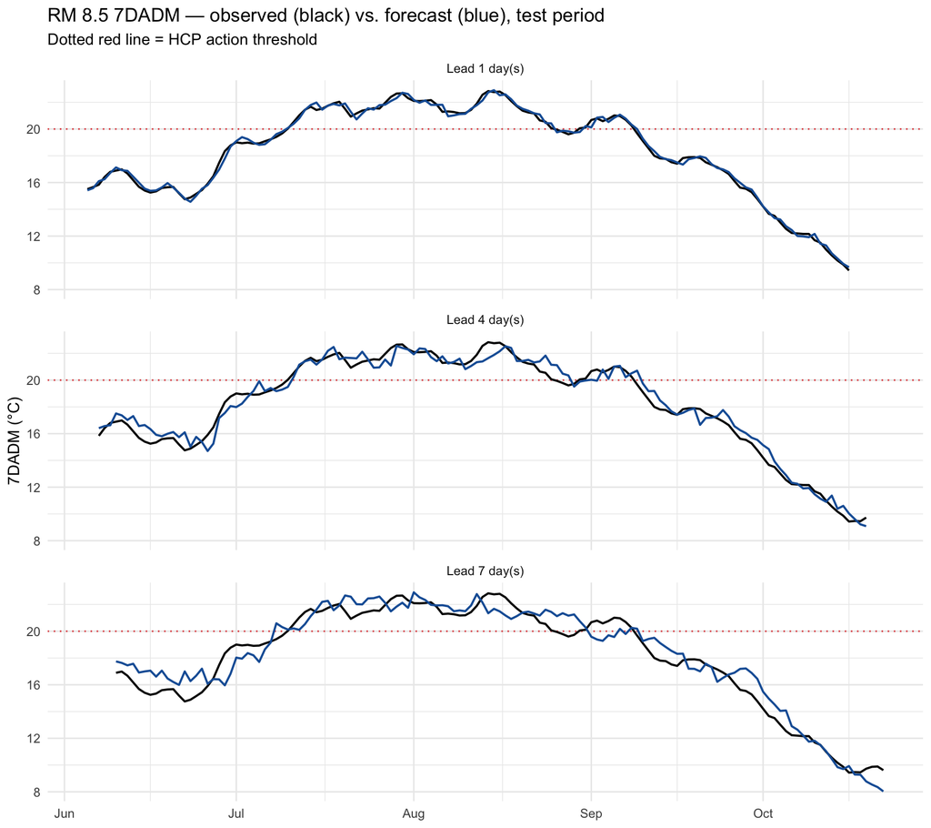

```r
test_long |>
  filter(lead %in% c(1, 4, 7)) |>
  mutate(panel = lead_label(lead)) |>
  ggplot(aes(x = date)) +
  geom_hline(yintercept = threshold_7dadm, linetype = "dotted", color = "#E24B4A") +
  geom_line(aes(y = observed), color = "black", linewidth = 0.7) +
  geom_line(aes(y = predicted), color = "#185FA5", linewidth = 0.7) +
  facet_wrap(~panel, ncol = 1) +
  labs(title = "RM 8.5 7DADM — observed (black) vs. forecast (blue), test period",
       subtitle = "Dotted red line = HCP action threshold",
       x = NULL, y = "7DADM (°C)") +
  theme_minimal()
```

# Variable importance by lead

`%IncMSE` is permutation importance: how much worse the model’s error gets when a single feature’s values are randomly shuffled, holding everything else fixed. Note that these forests predict the *change* from today, so importance here describes what drives the correction — not what drives the temperature level (which `dadm_m0` supplies directly).

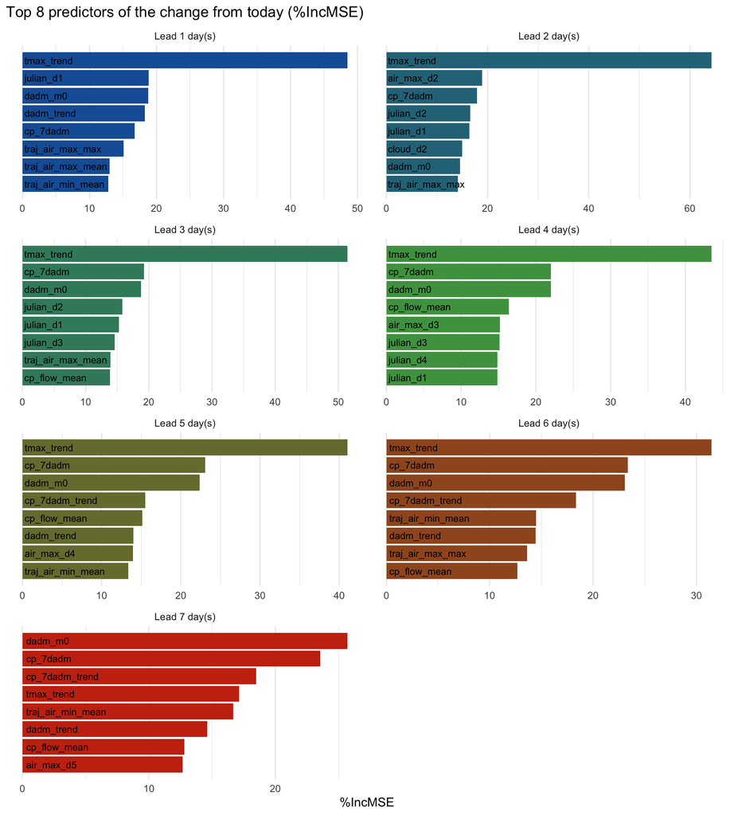

```r
importance_by_lead <- map_dfr(lead_days_vec, function(k) {
  imp <- importance(models_rf_delta[[as.character(k)]])
  tibble(lead = k, feature = rownames(imp), pct_inc_mse = imp[, "%IncMSE"])
})

top_n_features <- 8

importance_top <- importance_by_lead |>
  group_by(lead) |>
  slice_max(pct_inc_mse, n = top_n_features) |>
  arrange(lead, pct_inc_mse) |>
  mutate(feature_order = row_number()) |>
  ungroup()

ggplot(importance_top, aes(x = feature_order, y = pct_inc_mse, fill = factor(lead))) +
  geom_col() +
  geom_text(aes(label = feature, y = 0), hjust = 0, size = 3, nudge_y = 0.3) +
  coord_flip() +
  facet_wrap(~lead, scales = "free", ncol = 2,
             labeller = as_labeller(function(x) paste("Lead", x, "day(s)"))) +
  scale_fill_manual(values = lead_colors, guide = "none") +
  scale_x_continuous(breaks = NULL) +
  labs(title = paste("Top", top_n_features, "predictors of the change from today (%IncMSE)"),
       x = NULL, y = "%IncMSE") +
  theme_minimal()
```

# Real 2026 hindcast

Cached real NWS forecasts, a fresh Camp Polk pull, and the real RM 8.5 logger record. This is the evaluation that matters — it is the only one where the weather inputs come from the NWS product actually used operationally rather than from the GFS archive the model was trained on.

```r
nws_cached <- read_csv(here("output", "nws-forecasts-log.csv")) |>
  mutate(run_date = as.Date(run_date), forecast_date = as.Date(forecast_date))

rm_8_5_new <- readxl::read_xlsx(here("data-raw", "data-raw", rm85_logger_file)) |>
  janitor::clean_names()

rm_8_5 <- rm_8_5_new |>
  mutate(date = as.Date(lubridate::floor_date(date_time_pdt, "1 day"))) |>
  group_by(date) |>
  summarize(max = max(temperature_c, na.rm = TRUE), .groups = "drop") |>
  mutate(`7DADM` = zoo::rollapply(max, width = 7, FUN = mean, fill = NA, align = "right"))

rm_8_5_wide <- rm_8_5 |> select(date, actual_7dadm_C = `7DADM`, actual_tmax_C = max)

hindcast_run_dates <- nws_cached |>
  distinct(run_date) |>
  filter(run_date %in% rm_8_5_wide$date) |>
  pull(run_date) |>
  sort()

pull_start <- min(hindcast_run_dates) - 10
pull_end   <- max(hindcast_run_dates)

cp_flow_raw <- get_owrd_hydro("14076100", pull_start, pull_end, "MDF")
cp_tmax_raw <- get_owrd_hydro("14076100", pull_start, pull_end, "WTEMP15")

cp_flow_hc <- cp_flow_raw |>
  mutate(date = as.Date(parse_date_time(record_date, orders = c("mdy", "mdy HM")))) |>
  rename(cp_flow_mean = mean_daily_flow_cfs) |>
  select(date, cp_flow_mean) |>
  arrange(date)

cp_tmax_hc <- cp_tmax_raw |>
  mutate(date = as.Date(parse_date_time(record_date, orders = c("mdy", "mdy HM")))) |>
  group_by(date) |>
  summarise(cp_tmax = max(instantaneous_water_temp_c, na.rm = TRUE), .groups = "drop") |>
  arrange(date)

cp_7dadm_hc <- cp_tmax_hc |>
  mutate(cp_7dadm = zoo::rollmean(cp_tmax, k = 7, fill = NA, align = "right"))

cp_daily <- cp_flow_hc |>
  left_join(cp_tmax_hc, by = "date") |>
  left_join(select(cp_7dadm_hc, date, cp_7dadm), by = "date")
```

```r
safe1 <- function(x) if (length(x) == 0) NA_real_ else x

nws_daily <- function(var, target_date, agg_fn, run_date_val) {
  vals <- nws_cached |>
    filter(run_date == run_date_val, variable == var, forecast_date == target_date) |>
    pull(value)
  if (length(vals) == 0) return(NA_real_)
  agg_fn(vals, na.rm = TRUE)
}

build_hindcast_row <- function(run_date_val, k) {
  cp_today   <- cp_daily    |> filter(date == run_date_val)
  cp_yest    <- cp_daily    |> filter(date == run_date_val - 1)
  cp_trendw  <- cp_daily    |> filter(date == run_date_val - trend_window)
  rm85_today <- rm_8_5_wide |> filter(date == run_date_val)
  rm85_trendw<- rm_8_5_wide |> filter(date == run_date_val - trend_window)

  traj <- map(1:k, function(d) {
    tibble(
      !!paste0("air_max_d", d) := nws_daily("maxTemperature", run_date_val + d, max,  run_date_val),
      !!paste0("air_min_d", d) := nws_daily("minTemperature", run_date_val + d, min,  run_date_val),
      !!paste0("cloud_d",   d) := nws_daily("skyCover",       run_date_val + d, mean, run_date_val),
      !!paste0("julian_d",  d) := yday(run_date_val + d)
    )
  }) |> bind_cols()

  bind_cols(
    tibble(
      run_date = run_date_val, forecast_date = run_date_val + k, lead_days = k,
      cp_flow_mean   = safe1(cp_today$cp_flow_mean),
      cp_7dadm       = safe1(cp_today$cp_7dadm),
      cp_tmax        = safe1(cp_today$cp_tmax),
      cp_flow_trend  = (safe1(cp_yest$cp_flow_mean) - safe1(cp_trendw$cp_flow_mean)) / (trend_window - 1),
      cp_7dadm_trend = (safe1(cp_yest$cp_7dadm)     - safe1(cp_trendw$cp_7dadm))     / (trend_window - 1)
    ),
    traj,
    tibble(
      dadm_m0    = safe1(rm85_today$actual_7dadm_C),
      tmax_m0    = safe1(rm85_today$actual_tmax_C),
      dadm_trend = (safe1(rm85_today$actual_7dadm_C) - safe1(rm85_trendw$actual_7dadm_C)) / trend_window,
      tmax_trend = (safe1(rm85_today$actual_tmax_C)  - safe1(rm85_trendw$actual_tmax_C))  / trend_window
    )
  )
}

hindcast_grid   <- expand_grid(run_date = hindcast_run_dates, lead_days = lead_days_vec)
hindcast_inputs <- map2_dfr(hindcast_grid$run_date, hindcast_grid$lead_days, build_hindcast_row)

# Trajectory summaries must be added per lead, since they span d1..dk.
hindcast_by_lead <- map(lead_days_vec, function(k) {
  add_trajectory_summaries(hindcast_inputs |> filter(lead_days == k), k)
})
names(hindcast_by_lead) <- as.character(lead_days_vec)

cat(sprintf("Hindcast input rows: %d\n", nrow(hindcast_inputs)))
```

```
## Hindcast input rows: 651
```

```r
predict_for_lead <- function(k) {
  rows <- hindcast_by_lead[[as.character(k)]]
  features <- get_model_features(k)
  feat_x <- rows[, c(features, "dadm_m0"), drop = FALSE]
  ok <- complete.cases(feat_x)

  rows$pred_7dadm_C <- NA_real_
  if (any(ok)) {
    rows$pred_7dadm_C[ok] <- predict_rf_delta(models_rf_delta[[as.character(k)]], rows[ok, , drop = FALSE])
  }
  rows |> select(run_date, forecast_date, lead_days, dadm_m0, pred_7dadm_C)
}

hindcast_results <- map_dfr(lead_days_vec, predict_for_lead)

forecast_eval <- hindcast_results |>
  inner_join(rm_8_5_wide, by = c("forecast_date" = "date")) |>
  filter(!is.na(pred_7dadm_C), !is.na(actual_7dadm_C)) |>
  mutate(dadm_error = pred_7dadm_C - actual_7dadm_C,
         lead_days  = factor(lead_days, levels = lead_days_vec))

cat(sprintf("Forecast/observation pairs available for evaluation: %d\n", nrow(forecast_eval)))
```

```
## Forecast/observation pairs available for evaluation: 616
```

```r
metrics_table <- forecast_eval |>
  group_by(lead_days) |>
  summarise(n = n(), bias = mean(dadm_error), mae = mean(abs(dadm_error)),
            rmse = sqrt(mean(dadm_error^2)), .groups = "drop")

metrics_table |>
  kable(digits = 3, col.names = c("Lead (days)", "n", "Bias", "MAE", "RMSE"))
```

| Lead (days) | n | Bias | MAE | RMSE |
| --- | --- | --- | --- | --- |
| 1 | 91 | -0.054 | 0.212 | 0.271 |
| 2 | 90 | -0.039 | 0.327 | 0.408 |
| 3 | 89 | -0.042 | 0.443 | 0.541 |
| 4 | 88 | -0.062 | 0.591 | 0.748 |
| 5 | 87 | -0.113 | 0.711 | 0.889 |
| 6 | 86 | -0.108 | 0.800 | 1.009 |
| 7 | 85 | -0.205 | 0.815 | 1.012 |

## Warm conditions only

This filters the data to only include actual >= 20*C. We care more about whether the model performs well at warmer temperatures and this tests that.

```r
forecast_eval |>
  filter(actual_7dadm_C >= threshold_7dadm) |>
  group_by(lead_days) |>
  summarise(n = n(), bias = mean(dadm_error), mae = mean(abs(dadm_error)),
            rmse = sqrt(mean(dadm_error^2)), .groups = "drop") |>
  kable(digits = 3, col.names = c("Lead (days)", "n", "Bias", "MAE", "RMSE"))
```

| Lead (days) | n | Bias | MAE | RMSE |
| --- | --- | --- | --- | --- |
| 1 | 57 | -0.060 | 0.208 | 0.264 |
| 2 | 57 | -0.096 | 0.326 | 0.405 |
| 3 | 57 | -0.141 | 0.415 | 0.512 |
| 4 | 57 | -0.221 | 0.515 | 0.646 |
| 5 | 57 | -0.340 | 0.667 | 0.844 |
| 6 | 57 | -0.370 | 0.778 | 0.991 |
| 7 | 57 | -0.465 | 0.819 | 1.018 |

## Skill against persistence

A forecast is only worth running if it beats carrying today’s value forward. `dadm_m0` is exactly that null model, and because this design is anchored on it the comparison is the honest test of whether the forest is adding anything.

TODO: I don’t understand this.

```r
bind_rows(
  forecast_eval |> transmute(lead_days, err = dadm_error, model = "RF (change-from-today)"),
  forecast_eval |> transmute(lead_days, err = dadm_m0 - actual_7dadm_C, model = "persistence (dadm_m0)")
) |>
  group_by(model, lead_days) |>
  summarise(rmse = sqrt(mean(err^2)), .groups = "drop") |>
  pivot_wider(names_from = model, values_from = rmse) |>
  mutate(`skill gain` = `persistence (dadm_m0)` - `RF (change-from-today)`) |>
  kable(digits = 3)
```

| lead_days | RF (change-from-today) | persistence (dadm_m0) | skill gain |
| --- | --- | --- | --- |
| 1 | 0.271 | 0.442 | 0.171 |
| 2 | 0.408 | 0.787 | 0.379 |
| 3 | 0.541 | 1.064 | 0.523 |
| 4 | 0.748 | 1.308 | 0.560 |
| 5 | 0.889 | 1.509 | 0.620 |
| 6 | 1.009 | 1.671 | 0.662 |
| 7 | 1.012 | 1.763 | 0.751 |

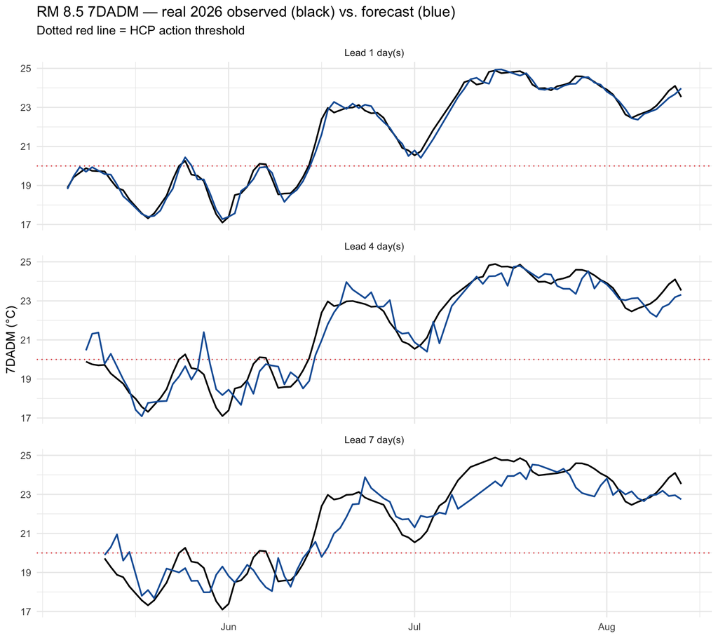

```r
forecast_eval |>
  mutate(lead_int = as.integer(as.character(lead_days))) |>
  filter(lead_int %in% c(1, 4, 7)) |>
  mutate(panel = lead_label(lead_int)) |>
  ggplot(aes(x = forecast_date)) +
  geom_hline(yintercept = threshold_7dadm, linetype = "dotted", color = "#E24B4A") +
  geom_line(aes(y = actual_7dadm_C), color = "black", linewidth = 0.7) +
  geom_line(aes(y = pred_7dadm_C), color = "#185FA5", linewidth = 0.7) +
  facet_wrap(~panel, ncol = 1) +
  labs(title = "RM 8.5 7DADM — real 2026 observed (black) vs. forecast (blue)",
       subtitle = "Dotted red line = HCP action threshold",
       x = NULL, y = "7DADM (°C)") +
  theme_minimal()
```

## Forecast vs. observed

The 1:1 line is the target. Spread widening with lead is expected; a tilt away from the diagonal would signal bias, and points drifting below it at the warm end would be the cold-bias failure this design was built to fix.

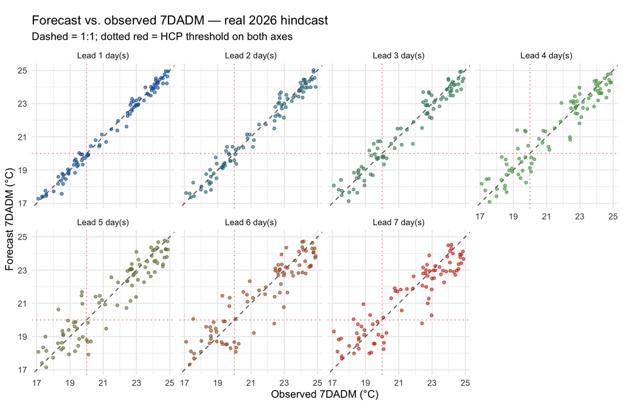

```r
forecast_eval |>
  mutate(panel = lead_label(as.integer(as.character(lead_days)))) |>
  ggplot(aes(x = actual_7dadm_C, y = pred_7dadm_C)) +
  geom_abline(slope = 1, intercept = 0, linetype = "dashed", color = "#666666") +
  geom_vline(xintercept = threshold_7dadm, linetype = "dotted", color = "#E24B4A", alpha = 0.6) +
  geom_hline(yintercept = threshold_7dadm, linetype = "dotted", color = "#E24B4A", alpha = 0.6) +
  geom_point(aes(color = lead_days), alpha = 0.6, size = 1.2) +
  facet_wrap(~panel, ncol = 4) +
  scale_color_manual(values = lead_colors, guide = "none") +
  coord_equal() +
  labs(title = "Forecast vs. observed 7DADM — real 2026 hindcast",
       subtitle = "Dashed = 1:1; dotted red = HCP threshold on both axes",
       x = "Observed 7DADM (°C)", y = "Forecast 7DADM (°C)") +
  theme_minimal()
```

## Error structure

Two things worth seeing that a summary table hides: how error spreads with lead, and whether it depends on how warm it actually is. The second panel is the direct check on warm-season behaviour — a flat line near zero across the x-axis is what “no warm bias” looks like.

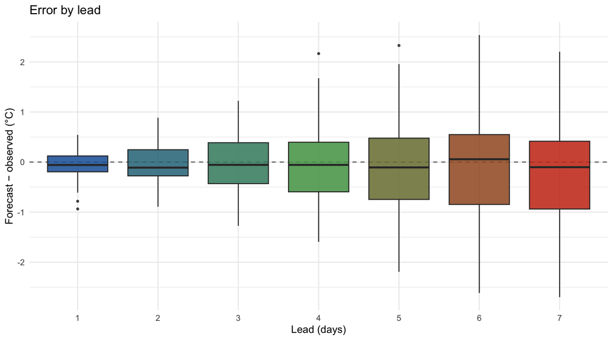

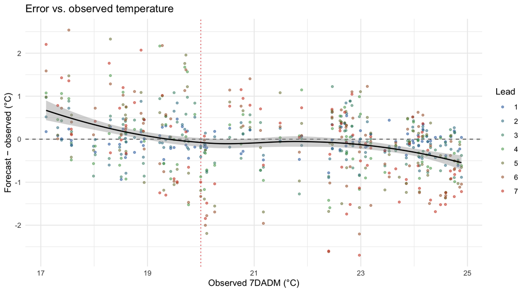

```r
p_box <- forecast_eval |>
  ggplot(aes(x = lead_days, y = dadm_error, fill = lead_days)) +
  geom_hline(yintercept = 0, linetype = "dashed", color = "#666666") +
  geom_boxplot(alpha = 0.85, outlier.size = 0.8) +
  scale_fill_manual(values = lead_colors, guide = "none") +
  labs(title = "Error by lead", x = "Lead (days)", y = "Forecast − observed (°C)") +
  theme_minimal()

p_warm <- forecast_eval |>
  ggplot(aes(x = actual_7dadm_C, y = dadm_error)) +
  geom_hline(yintercept = 0, linetype = "dashed", color = "#666666") +
  geom_vline(xintercept = threshold_7dadm, linetype = "dotted", color = "#E24B4A") +
  geom_point(aes(color = lead_days), alpha = 0.5, size = 1) +
  geom_smooth(method = "loess", se = TRUE, color = "black", linewidth = 0.7) +
  scale_color_manual(values = lead_colors, name = "Lead") +
  labs(title = "Error vs. observed temperature",
       x = "Observed 7DADM (°C)", y = "Forecast − observed (°C)") +
  theme_minimal()

print(p_box); print(p_warm)
```

## Skill against persistence, by lead

TODO - I don’t understand this

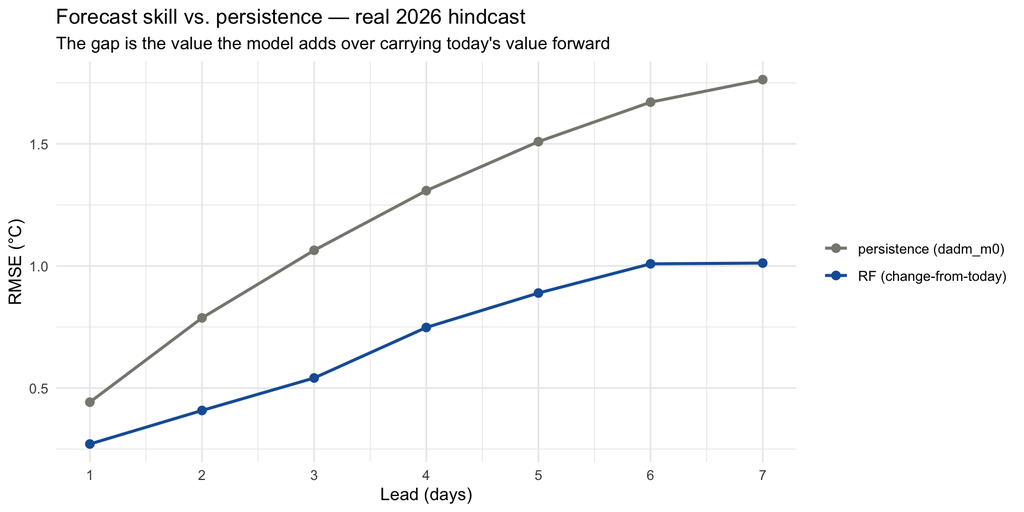

```r
bind_rows(
  forecast_eval |> transmute(lead = as.integer(as.character(lead_days)),
                             err = dadm_error, model = "RF (change-from-today)"),
  forecast_eval |> transmute(lead = as.integer(as.character(lead_days)),
                             err = dadm_m0 - actual_7dadm_C, model = "persistence (dadm_m0)")
) |>
  group_by(model, lead) |>
  summarise(rmse = sqrt(mean(err^2)), .groups = "drop") |>
  ggplot(aes(x = lead, y = rmse, color = model)) +
  geom_line(linewidth = 0.9) +
  geom_point(size = 2.2) +
  scale_color_manual(values = c("RF (change-from-today)" = "#185FA5",
                                "persistence (dadm_m0)" = "#888780"), name = NULL) +
  scale_x_continuous(breaks = lead_days_vec) +
  labs(title = "Forecast skill vs. persistence — real 2026 hindcast",
       subtitle = "The gap is the value the model adds over carrying today's value forward",
       x = "Lead (days)", y = "RMSE (°C)") +
  theme_minimal()
```

# Threshold-exceedance performance

Beyond raw temperature error, what matters operationally is whether the forecast correctly flags days that cross the HCP action threshold (7DADM >= 20°C). Each forecast/observation pair falls into one of four outcomes:

- **True positive (TP)**: forecast predicted exceedance, and it actually happened.
- **True negative (TN)**: forecast predicted no exceedance, and none happened.
- **False positive (FP)**: forecast predicted exceedance, but it didn’t happen (a false alarm).
- **False negative (FN)**: forecast predicted no exceedance, but one happened (a missed exceedance).
- **Accuracy** = (TP + TN) / n — the share of all forecasts that got the exceed/no-exceed call right, in either direction.
- **Sensitivity** (recall) = TP / (TP + FN) — of the days that actually exceeded, the fraction the model caught. Low sensitivity means missed exceedances, the operationally riskier failure mode.
- **Specificity** = TN / (TN + FP) — of the days that did *not* exceed, the fraction correctly left unflagged. Low specificity means false alarms.
- **Precision** = TP / (TP + FP) — of the days the model flagged, the fraction that actually exceeded.

```r
exceedance_eval <- forecast_eval |>
  mutate(actual_exceed = actual_7dadm_C >= threshold_7dadm,
         pred_exceed   = pred_7dadm_C   >= threshold_7dadm)

confusion_summary <- function(df, pred_col, actual_col) {
  df <- df |> filter(!is.na({{ pred_col }}), !is.na({{ actual_col }}))
  pred <- df |> pull({{ pred_col }}); actual <- df |> pull({{ actual_col }})
  tp <- sum(pred & actual); tn <- sum(!pred & !actual)
  fp <- sum(pred & !actual); fn <- sum(!pred & actual)
  tibble(n = nrow(df), accuracy = (tp + tn) / nrow(df),
         sensitivity = if (tp + fn > 0) tp / (tp + fn) else NA_real_,
         specificity = if (tn + fp > 0) tn / (tn + fp) else NA_real_,
         precision   = if (tp + fp > 0) tp / (tp + fp) else NA_real_)
}

exceedance_eval |>
  group_by(lead_days) |>
  group_modify(~ confusion_summary(.x, pred_exceed, actual_exceed)) |>
  ungroup() |>
  kable(digits = 2,
        col.names = c("Lead (days)", "n", "Accuracy", "Sensitivity", "Specificity", "Precision"))
```

| Lead (days) | n | Accuracy | Sensitivity | Specificity | Precision |
| --- | --- | --- | --- | --- | --- |
| 1 | 91 | 0.96 | 0.95 | 0.97 | 0.98 |
| 2 | 90 | 0.94 | 0.96 | 0.91 | 0.95 |
| 3 | 89 | 0.90 | 0.93 | 0.84 | 0.91 |
| 4 | 88 | 0.90 | 0.93 | 0.84 | 0.91 |
| 5 | 87 | 0.90 | 0.91 | 0.87 | 0.93 |
| 6 | 86 | 0.90 | 0.91 | 0.86 | 0.93 |
| 7 | 85 | 0.92 | 0.93 | 0.89 | 0.95 |

Where the calls land in time matters as much as the rates. Misses clustering on particular days points at a shared cause rather than random error — and they do cluster, hard.

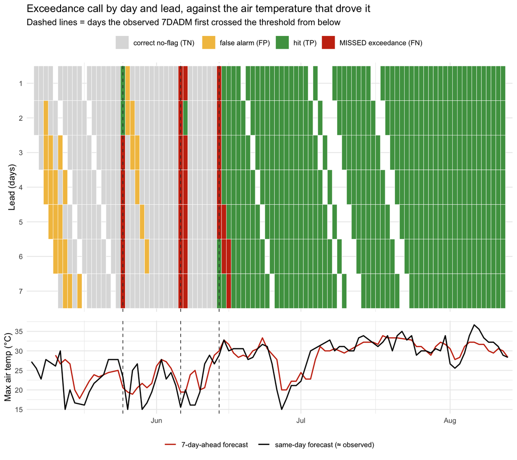

```r
# Days the OBSERVED series first crossed the threshold from below. Reused
# by the miss-anatomy tables below.
crossings <- rm_8_5_wide |>
  arrange(date) |>
  filter(!is.na(actual_7dadm_C)) |>
  mutate(above = actual_7dadm_C >= threshold_7dadm,
         crossing = above & !lag(above)) |>
  filter(crossing) |>
  select(crossing_date = date, obs_7dadm = actual_7dadm_C)

date_rng <- range(exceedance_eval$forecast_date)

p_heat <- exceedance_eval |>
  mutate(outcome = case_when(
    pred_exceed &  actual_exceed ~ "hit (TP)",
    !pred_exceed & !actual_exceed ~ "correct no-flag (TN)",
    pred_exceed & !actual_exceed ~ "false alarm (FP)",
    TRUE ~ "MISSED exceedance (FN)")) |>
  ggplot(aes(x = forecast_date, y = fct_rev(lead_days), fill = outcome)) +
  geom_tile(color = "white", linewidth = 0.2) +
  geom_vline(data = crossings, aes(xintercept = crossing_date),
             linetype = "dashed", color = "#333333", linewidth = 0.4) +
  scale_fill_manual(values = c("hit (TP)" = "#4E9F50",
                               "correct no-flag (TN)" = "#DDDDDD",
                               "false alarm (FP)" = "#F2C14E",
                               "MISSED exceedance (FN)" = "#C93312"), name = NULL) +
  scale_x_date(limits = date_rng, expand = expansion(mult = 0.01)) +
  labs(title = "Exceedance call by day and lead, against the air temperature that drove it",
       subtitle = "Dashed lines = days the observed 7DADM first crossed the threshold from below",
       x = NULL, y = "Lead (days)") +
  theme_minimal() +
  theme(legend.position = "top", axis.text.x = element_blank())

air_panel <- nws_cached |>
  filter(variable == "maxTemperature", lead_days %in% c(0, 7)) |>
  group_by(forecast_date, lead_days) |>
  summarise(air_max = max(value, na.rm = TRUE), .groups = "drop") |>
  filter(forecast_date >= date_rng[1], forecast_date <= date_rng[2]) |>
  mutate(series = if_else(lead_days == 0,
                          "same-day forecast (≈ observed)", "7-day-ahead forecast"))

p_air <- ggplot(air_panel, aes(x = forecast_date, y = air_max, color = series)) +
  geom_vline(data = crossings, aes(xintercept = crossing_date),
             linetype = "dashed", color = "#333333", linewidth = 0.4) +
  geom_line(linewidth = 0.7) +
  scale_color_manual(values = c("same-day forecast (≈ observed)" = "black",
                                "7-day-ahead forecast" = "#C93312"), name = NULL) +
  scale_x_date(limits = date_rng, expand = expansion(mult = 0.01)) +
  labs(x = NULL, y = "Max air temp (°C)") +
  theme_minimal() +
  theme(legend.position = "bottom")

plot_grid(p_heat, p_air, ncol = 1, align = "v", axis = "lr", rel_heights = c(2.2, 1))
```

### What the misses actually are

Almost every missed exceedance falls on one of a handful of dates, and those dates turn out to be the same thing each time.

```r
miss_dates <- exceedance_eval |>
  filter(!pred_exceed, actual_exceed) |>
  count(forecast_date, name = "leads_missed") |>
  arrange(desc(leads_missed))

# `crossings` is defined with the heatmap above.
miss_dates |>
  mutate(`is a first crossing?` = if_else(forecast_date %in% crossings$crossing_date, "yes", "no")) |>
  kable(digits = 2, col.names = c("Forecast date", "Leads missed", "Is a first crossing?"))
```

| Forecast date | Leads missed | Is a first crossing? |
| --- | --- | --- |
| 2026-06-06 | 7 | yes |
| 2026-06-07 | 6 | no |
| 2026-05-25 | 5 | yes |
| 2026-06-14 | 5 | yes |
| 2026-06-15 | 2 | no |
| 2026-06-16 | 2 | no |

```r
fn <- exceedance_eval |> filter(!pred_exceed, actual_exceed) |>
  mutate(required_change = actual_7dadm_C - dadm_m0,
         predicted_change = pred_7dadm_C - dadm_m0)

tibble(
  metric = c("Missed exceedances (rows)",
             "…that are marginal (observed < 20.5°C)",
             "Median observed on missed days (°C)",
             "Median forecast on missed days (°C)",
             "Median rise actually required (°C)",
             "Median rise the model predicted (°C)",
             "Median shortfall (°C)",
             "Median required rise, ALL days (°C)"),
  value = c(nrow(fn),
            sum(fn$actual_7dadm_C < 20.5),
            median(fn$actual_7dadm_C),
            median(fn$pred_7dadm_C),
            median(fn$required_change),
            median(fn$predicted_change),
            median(fn$required_change - fn$predicted_change),
            median(exceedance_eval$actual_7dadm_C - exceedance_eval$dadm_m0))
) |> kable(digits = 2)
```

| metric | value |
| --- | --- |
| Missed exceedances (rows) | 27.00 |
| …that are marginal (observed < 20.5°C) | 23.00 |
| Median observed on missed days (°C) | 20.11 |
| Median forecast on missed days (°C) | 19.40 |
| Median rise actually required (°C) | 1.78 |
| Median rise the model predicted (°C) | 1.02 |
| Median shortfall (°C) | 1.04 |
| Median required rise, ALL days (°C) | 0.03 |

**The model does not miss warm days — it misses the transition into warm.** Over the whole season the observed 7DADM crossed the threshold from below exactly 3 times (May 25, Jun 06, Jun 14), and every one of them is a miss cluster. Once the site is established above 20°C the model tracks it correctly for weeks — that is the uninterrupted green on the right of the heatmap.

The false alarms have the opposite cause: on those rows the NWS air-max forecast ran **+2.5°C too warm** (MAE 3.45°C), roughly double the error of any other outcome. So the two failure modes are separable — misses are a model limitation on transitions, false alarms are an input limitation — and they warrant different responses. Nothing is gained by tuning one threshold to trade between them.

The practical hedge, given that all of this concentrates on three or four predictable days a season: treat a forecast in the high 19s during a rising trend as a soft exceedance warning rather than a clean negative. `rm85-rf-delta-quantiles.Rmd` does this properly — it puts a probability on the crossing instead of a binary call, which is precisely the case these misses represent.

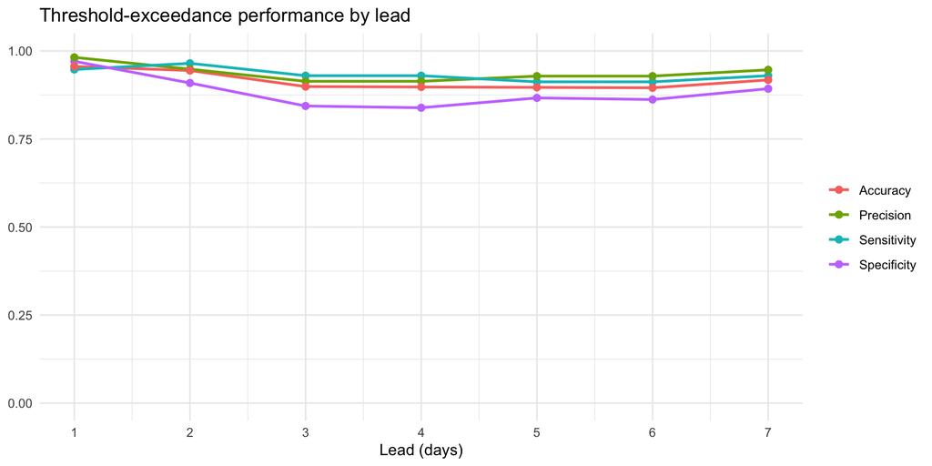

```r
exceedance_eval |>
  group_by(lead_days) |>
  group_modify(~ confusion_summary(.x, pred_exceed, actual_exceed)) |>
  ungroup() |>
  select(lead_days, Sensitivity = sensitivity, Specificity = specificity,
         Precision = precision, Accuracy = accuracy) |>
  pivot_longer(-lead_days, names_to = "metric", values_to = "value") |>
  ggplot(aes(x = as.integer(as.character(lead_days)), y = value, color = metric)) +
  geom_line(linewidth = 0.9) + geom_point(size = 2) +
  scale_x_continuous(breaks = lead_days_vec) +
  scale_y_continuous(limits = c(0, 1)) +
  labs(title = "Threshold-exceedance performance by lead",
       x = "Lead (days)", y = NULL, color = NULL) +
  theme_minimal()
```

# Potential improvements

Ordered by expected value for the operational decision this feeds — a 7-day-ahead exceedance call that can result in irrigators being asked to shut off water. Each entry says what it would fix and why that matters here, so the list can be triaged rather than worked through in order.

**3. Propagate weather-forecast uncertainty with a GEFS ensemble.** The quantile model captures the spread of *water* temperature given the weather forecast it was handed; it does not represent error in that forecast. Yet the diagnosis above shows false alarms are driven almost entirely by the NWS air-max forecast running about +2.5°C too warm (MAE 3.45°C, roughly double any other outcome). At a 7-day lead the weather forecast is the dominant error source, so running the model once per GEFS ensemble member and taking the spread would address the largest remaining uncertainty rather than a residual one.

**4. Conformalize the prediction intervals.** The interval calibration in the quantile document — sweeping the nominal level until empirical coverage hits 80% — is an ad-hoc version of split conformal prediction. Conformalized Quantile Regression does it properly and carries a finite-sample coverage guarantee under exchangeability, while keeping the lead-dependent adaptivity. Modest work; strictly firmer footing for intervals that inform consequential decisions.

**5. Build the predictive distribution from the operational log itself.** `output/nws-forecasts-log.csv` has been accumulating real forecasts since May 2026. Once there are two or three seasons, the distribution of *realized* forecast errors at each lead is the ideal uncertainty estimate: it automatically includes model error, weather-input error, and regime drift, none of which a model trained on a historical archive can fully see. This is the long-run destination — it needs only patience and protecting that log, which is unreproducible if lost.

**6. Monitor running bias rather than assuming stability.** The Camp Polk-to-RM 8.5 relationship shifted around 2022 and has held at the new level since; a record season is exactly when the next shift would appear. A trailing 30-day bias check against observations, with an alert threshold, would catch drift before it became a season-long problem.

Two things deliberately **not** on this list, having been tested and rejected: switching the weather training source (Open-Meteo Previous Runs vs dynamical.org made no significant difference, p = 0.46), and adding seasonal-anomaly features (significantly worse — in a record year the anomaly itself falls outside the training range, so the forest saturates on it and dilutes the predictors that work).

# Saved artifacts

```r
walk(lead_days_vec, function(k) {
  saveRDS(models_rf_delta[[as.character(k)]],
          here("output", paste0("rm85_rf_7dadm_delta_lead", k, ".rds")))
})
cat("Models saved to output/rm85_rf_7dadm_delta_lead*.rds\n")
```

```
## Models saved to output/rm85_rf_7dadm_delta_lead*.rds
```

**These models return a change, not a temperature.** Any consumer must add `dadm_m0` (RM 8.5’s observed 7DADM on the run date) back:

```r
pred_7dadm <- predict(model, newdata) + newdata$dadm_m0
```

`analysis/summer_2026_8_5_performance.Rmd` does this via the same `predict_rf_delta()` helper defined above.